# Where will a new Airbnb user make their first booking?

### DAT 10

### Kate Riesbeck

# The Question

Airbnb (www.airbnb.com) is a travel website for people to list, find, and rent lodging. It has over 1,500,000 listings in 34,000 cities and 190 countries.

Kaggle (www.kaggle.com) is a website for predictive modelling and analytics competitions.

Airbnb is hosting a Kaggle competition asking data scientists to **predict in which country a new Airbnb user will book their first travel experience.** Successful models will allow Airbnb to personalize content, decrease the average time to first booking, and better forecast demand.

# The Data

AirBnB has provided 6 datasets:

- train_users2.csv - the training set of users
- test_users.csv - the test set of users
- sessions.csv - web sessions log for users
- countries.csv - summary statistics of destination countries in this dataset and their locations
- age_gender_bkts.csv - summary statistics of users' age group, gender, country of destination
- sample_submissionNDF.csv - sample of the required submission format

# Exploratory Data Analysis

- The train data contains a unique id, 14 features (gender, age, signup method, language, etc.), and the response (country destination).
- All the users in this dataset are from the USA.
- There are 12 possible outcomes of the destination country: 'US', 'FR', 'CA', 'GB', 'ES', 'IT', 'PT', 'NL','DE', 'AU', 'NDF' (no destination found), and 'other'.
  - Note that 'NDF' is different from 'other' because 'other' means there was a booking, but is to a country not included in the list, while 'NDF' means there wasn't a booking.
- The response is categorical, so this is a classification question.

```python
##Check out the response variable

train.country_destination.value_counts()
```

```
NDF      124543
US        62376
other     10094
FR         5023
IT         2835
GB         2324
ES         2249
CA         1428
DE         1061
NL          762
AU          539
PT          217
Name: country_destination, dtype: int64
```

```python
##sessions: feature engineering
  ##feature ideas:  large secs_elapsed, large number of interactions, something with action_detail?

sessions.head()
```

|  | user_id | action | action_type | action_detail | device_type | secs_elapsed |
| --- | --- | --- | --- | --- | --- | --- |
| 0 | d1mm9tcy42 | lookup | NaN | NaN | Windows Desktop | 319 |
| 1 | d1mm9tcy42 | search_results | click | view_search_results | Windows Desktop | 67753 |
| 2 | d1mm9tcy42 | lookup | NaN | NaN | Windows Desktop | 301 |
| 3 | d1mm9tcy42 | search_results | click | view_search_results | Windows Desktop | 22141 |
| 4 | d1mm9tcy42 | lookup | NaN | NaN | Windows Desktop | 435 |

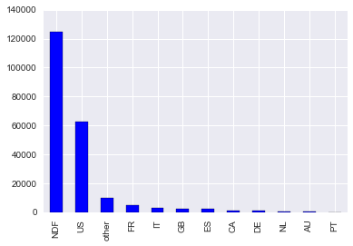

```python
##Response buckets and distribution.

train.country_destination.value_counts().plot(kind="bar")

##  'NDF' = 'No Destination Found'
##  'other' = First booking in a country not categorized
##Nearly 125k train records have not yet booked their first destination.
```

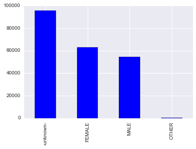

```python
train.gender.value_counts().plot(kind='bar', by='country_destination')
```

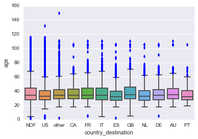

```python
sns.boxplot(x='country_destination', y='age', data=train_clean_ages)
```

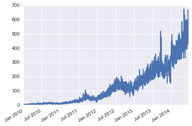

```python
train.date_account_created.value_counts().plot(kind='line')
```

# Next Steps

- Deal with missing/weird data
  - Ages > 150
- Create dummy variables for catagorical variables
- Join session dataset with train dataset
- Feature engineering
  - Sessions
  - Summary statistics for countries, age_gender (distance from US? language == english?)
- Apply machine learning techniques
  - Correlation matrix (after creating dummy variables)
  - KNN